# Week 7: Text analysis

Dani Cosme

2021-04-21

# resources

Here are a number of helpful resources to dig deeper into text processing and analysis:

**Tutorials**

- [UO data science seminar text processing](https://robchavez.github.io/datascience_gallery/html_only/text_processing.html)
- [An Introduction to Text Processing and Analysis with R](https://m-clark.github.io/text-analysis-with-R/)
- [Welcome to Text Mining with R](https://www.tidytextmining.com/index.html)

**Cheat sheets**

- [Strings](https://github.com/rstudio/cheatsheets/raw/master/strings.pdf)
- [Regular expressions](https://github.com/rstudio/cheatsheets/raw/master/regex.pdf)
- [More useful cheat sheets!](https://www.rstudio.com/resources/cheatsheets/)

# load packages

```r
if (!require(pacman)) {
  install.packages("pacman")
}
pacman::p_load("tidyverse", "here", "tidytext", "ggwordcloud", "knitr", "reactable",
               install = TRUE)
```

# load the data file

Modify the path as needed to where your `week4_data.csv` file is downloaded. Note, my path is a little different, but for you, it should be in the `data/` directory in the same folder as this script.

Import the csv file and assign it to the variable `data`

```r
data = read_csv(here("static", "labs", "data", "week4_data.csv"))
```

# tidy the data

The key variables we’ll be working with today are as follows:

- `behavior_voting`: voted in 2020; single dichotomous item, yes or no
- `advantages`: open-ended question about the advantages of voting
- `disadvantages`: open-ended question about the disadvantages of voting
- `barriers`: open-ended question about the barriers of voting
- `solutions`: open-ended question about the solutions of voting

```r
data_tidy = data %>%
  # filter out test and incomplete responses
  filter(!DistributionChannel == "preview") %>%
  filter(Finished == 1 & consent == 1) %>%
  # select a subset of variables
  select(ResponseId, behavior_voting, advantages, disadvantages, barriers, solutions) %>%
  # convert responses to numeric and recode response values
  mutate(behavior_voting = recode(behavior_voting,
                                  "1" = "yes",
                                  "2" = "no"))
```

Let’s check out what the tidied data look like

```r
data_tidy
```

| ResponseId | behavior_voting | advantages | disadvantages | barriers | solutions |
| --- | --- | --- | --- | --- | --- |
| R_3Gp961UT9BNkxCF | yes | you have some impact in making your voice heard | Some states make the process of voting extremely technical. Often times many ballots get tossed out because people were just unaware of how to complete the form properly. | Student do not get time off to vote. If one has class most of the day this becomes a large issue. | Spreading knowledge about the correct ways to send in a mail ballot and other similar information. |
| R_2abjLOinVp5zcvo | no | Making sure your voice is being heard. | Time-consuming | Perhaps being unaware of how/where to vote | Making sure it is very easy and not time-consuming to vote. |
| R_3lun7JrZiOjYkgo | yes | You get to exercise your constitutional right. You get a say in who are the leaders of the country. | Long lines, sometimes it's inconvenient to vote. | They don't feel like they have a voice. They feel like they aren't informed enough to vote. | Inform other students, encourage them to vote. |
| R_40VV5bSVDU5LZL3 | no | That you get to do your civic duty and have your voice heard | It can be a long and tedious process with lines, etc. | The long lines, not knowing how or where, etc. | By informing each other through social media since a lot of us are on there |
| R_1mn6vlqCbDaVVNw | no | Exercising your right that the people before you fought for. I think one of the greatest advantages of voting is that it encourages you to educate yourself and to have an opinions about something. | Voting could potentially cause polarization, as there will be a winner and a loser, and in theory, it pits people against one another. | The greatest barrier to voting for students, is for those who live out of state. I will not receive my ballot in time to vote, and that is incredibly frustrating. | I am not sure that students can really help that. I suppose students can help other students from their state get organized early, and request the ballot a month or more in advance, so that it will ar… |
| R_3qmQoXEqLFh7Kn1 | yes | Exercising your rights as a citizen | There are no candidates that I wish to support | It's an annoying process, especially this year | Set up ways to vote here on campus |
| R_C9wzCa09R7kujVD | yes | Your opinion is taken into account. | In this election year, safety at the poll is a concern. | time and distance | Plan! I planned how I would vote so that I couldn't say "I don't have time" or "I don't know how to vote" |
| R_3JhnTdSOc1WYLQO | yes | Letting the country be run in the way the people want it to. | Sometimes allows for tyranny of majority groups | I don't really see any barriers specifically for students | Encourage each other to vote no matter what (even if they have to wait in lines, stand in the rain, etc.) |
| R_BJRHkQN8EEmZYxb | yes | Is a surefire way of contributing to your community | Must recognize that you supported someone even if they ended up doing damage to the country | Transportation to polls | Carpool to polls, organize group travel |
| R_1Q57Htl3BkVeu8Z | yes | Doing your civic duty | Being swayed to vote for a particular candidate | Not having classes off on election day | We can mail in early or plan accordingly, but it would be better if universities gave us classes off |

[output cut: 156 more lines]

# make a table

## basic table using knitr::kable()

Let’s make a table to present the raw text for the advantages and disadvantages questions

```r
data_tidy %>%
  select(advantages, disadvantages) %>%
  kable(format = "pandoc")
```

| advantages | disadvantages |
| --- | --- |
| you have some impact in making your voice heard | Some states make the process of voting extremely technical. Often times many ballots get tossed out because people were just unaware of how to complete the form properly. |
| Making sure your voice is being heard. | Time-consuming |
| You get to exercise your constitutional right. You get a say in who are the leaders of the country. | Long lines, sometimes it’s inconvenient to vote. |
| That you get to do your civic duty and have your voice heard | It can be a long and tedious process with lines, etc. |
| Exercising your right that the people before you fought for. I think one of the greatest advantages of voting is that it encourages you to educate yourself and to have an opinions about something. | Voting could potentially cause polarization, as there will be a winner and a loser, and in theory, it pits people against one another. |
| Exercising your rights as a citizen | There are no candidates that I wish to support |
| Your opinion is taken into account. | In this election year, safety at the poll is a concern. |
| Letting the country be run in the way the people want it to. | Sometimes allows for tyranny of majority groups |
| Is a surefire way of contributing to your community | Must recognize that you supported someone even if they ended up doing damage to the country |
| Doing your civic duty | Being swayed to vote for a particular candidate |
| having a say in the future of our country | being criticized for voting for a specific candidate |
| Having a say in who runs the country | It might be a difficult thing for people from certain areas or backgrounds to do |
| Voicing my view and influencing who takes office | none |
| If the candidate I favor doesn’t get elected, I would not regret because I did my part by voting. | Allowing the candidate I don’t favor to have a slight increase of advantage of winning. |
| Having a say in how the US will proceed as a country. | It sometimes feels like individual voices do not affect change. |
| having a voice in how I want America to be | politicians may ignore what you want once they get elected (assuming they don’t need to be reelected) |
| It always you to voice your opinion and be an agent of change. | It takes some time to go through the process |
| being a part of our countries democracy and supporting my preferred candidate | the candidate I voted for is not my favorite, but is the best option |
| being able to express your views on the candidates and their policies | time-consuming and having little to no impact on the outcome |
| Having your voice heard, making a change | Not every vote counts the same |
| Influencing the election | Long lines and confusing registration process |
| Democratically electing government leaders | As far as America goes, we are given 2 options and if you don’t like either you can’t do anything about it. Voting third party is unfortunately essentially a waste. |
| exerting your right and helping form our democracy | there are none |
| Being able to vote allows me to have a say in what’s going on in our government. | With how our voting system is set up (the electoral college), sometimes it seems like even when we vote, we don’t have a say. For example, last election Hilary Clinton won the popular vote, but Trump … |
| Individuals get to participate in democracy and select their representatives | Uninformed people making decisions |
| Being able to engage with the future of the country; main way to contribute to what the government will look like. Important civic duty. | No candidate for any party is ever perfect. Chances are, you need to compromise on some of your beliefs for each person you vote for. |
| To directly participate in our democracy and choose our leader | The physical process and currently exposing yourself to potential infection |
| Partaking in a decision that will influence our country for the next four years | If I am not fully informed of the stances of the politicians, I could make a decision that will negatively influence my nation or local community |
| getting rid of the evil Trump | waiting in a long line |
| having a voice | having to choose between candidates who don’t represent one’s personal values |

[output cut: 78 more lines]

The system is still corruptible. In the American context, this was especially observable in the Jim Crow South, which selectively disenfranchised African American voters. In modern times, the Democrats tend to point to voter suppression while the Republicans tend to point to voter fraud. Bottom line: the system could be improved and made more transparent. Personally, I would make the vote counts completely digital and encrypted such that an automated computer program determines the results with bipartisan oversight. Additionally, I would remove mail-in absentee ballots with very very limited exceptions; e.g. you can vote for your state electronically across state-lines at a voting booth. There are various other things that I would do, e.g. data encryption with randomized encryption keys. This technology is available and is used in many other walks of life.

The news outlets don’t spread facts. It’s biased and absurd, on both sides. The average American cannot know the facts, nor do the established parties really want them to. At this point, I don’t know the facts. It seems that people are living in two very different realities because of the lack of this essential basis.

A vote for a third party is pretty much meaningless (in my opinion). Many people don’t agree with a political party on every issue. With the two party system, you are forced to vote for the better of two evils, which is simply based on some sort of coalition that will give a party the most votes rather than improve the country.

I really got on my soapbox for that one (sorry). You have a great opportunity to voice your opinion. It is better than not being able to vote, which would be a complete muting of one’s personal voice. Sometimes people don’t think that their vote really matters and counts when their opinion is not shared by the majority.  
It is the most direct and easiest way in which we are average day citizens can impact policy and what our country looks like. It also incentivizes me to be more informed about issues in my community. Sometimes, if a ballot allows you to vote along party lines, it can cause people to be just as little as informed about issues that they previously were. Also, in terms of amendments and new ballot initiatives, I often find that people are completely ignorant to the meat of the issue at hand and can vote based off a few words that they see.  
feeling like you did something? waiting in line  
Your vote is your voice Better policies for yourself and others Civic duty None  
You are completing a duty you have as a citizen Time commitment (that’s the biggest disadvantage I could think of, and it’s not even a big one)  
It represents the ideals of the foundation in which America was built and allows everyone to take part in the country’s well-being. The social discourtesy that is expressed when presented with differing opinions regarding candidate choices is disadvantageous.  
Participating in democracy having to make a hard moral choice  
Voicing your opinion. Getting the right people elected. Nothing  
If you don’t vote, you don’t get to complain about the outcome. Still can be kind of limited in the impact you can have on American politics. It is definitely a more complicated process than it needs to be.  
your voice counts and matters! staying informed about things happening and making your voice heard if you live in a state that’s already very blue, etc. I see why some people don’t think their vote “matters” which isn’t good, but I think it’s still important to vote. I guess a possible disadvantage is that people don’t always make informed decisions.  
it shows that democracy is working and a part of the process of democracy can be a long and timely process to ensure the most accurate results  
voicing your opinion and making a difference there aren’t  
You get to have a say in the democratic process. I can’t really see any, but potentially it’s disagreeing with someone else.  
The possible positive impact on selecting better leaders for the country. The symbolic benefit of feeling more tied and involved in one’s country. Wasted time to vote, or the energy that goes into learning enough about candidates to cast a good vote. You could possibly make the wrong choice and help put bad leaders in power. Maybe being too politically engaged in general ends up being a bad thing for individuals and voting could help with that  
Making your voice heard Two party system/limited choices  
Getting a leader that’s fit to represent your country and make it look good. Lack of access for certain people. Perhaps voter fraud in this election.  
Having every voice be heard People hopping on the bandwagon and only voting for what’s considered to be “in” as opposed to what they really stand for. Some people may vote for people just because of their name (i.e. the people who voted for Kanye West). I’m not sure how to exactly describe this disadvantage but I defiantly think it is one. I guess I could say people not really doing their research on the candidates is the disadvantage.  
It’s our duty to vote in our democracy and by voting in this election I was able to elect someone who I think will unite our country and be better for human rights and help those less fortunate than me. You don’t get to have a voice in what happens in your life  
Participating in the political process, having your voice heard and considered. N/a  
Feeling like you made your voice heard, having some say in what happens in the government Voting often changes very little  
It is a trusted process that can create change from a top down view. It also is important in uniting the nation depending on which candidates are selected A disadvantage is that voting maintains the current system which some might say is not currently working.  
I think that voting is the best way to express the people’s opinions to the government on a widespread level. I don’t see any disadvantages to voting.  
Creating change and having a voice/say in society in what you believe to be right. A possible disadvantage would be losing the election despite winning the popular vote.  
Be a part of the democratic system, make your voice and opinions heard May seem to be belittled by either the electoral college or their lack of personal importance.  
peaceful transition of power, using your voice NA  
Feeling like you made a positive contribution. The only disadvantage was the time commitment which was worth it.  
Voicing for our own community and identity. How voting can be used as a political toy.  
It allows you to have some influence in the leadership of something important to me You sometimes have to choose the lesser of two evils and aren’t particularly passionate about their stances  
Letting your voice be heard Other people who hold different views and publicize them way too much  
Participating in democracy and making your voice heard The difficulties associated with voting and making sure your ballot is counted  
you get to share your opinion nothing  
Voice is heard Inconvenient  
To me, voting allows you to exercise your ability to make a difference in your community. I don’t see a disadvantage. It’s easy, it’s important, and it actually makes a difference  
The greatest advantage to voting is being able to elect officials that serve the interests of yourself and your community. A disadvantage of voting is many people solely vote based on party lines instead of fully understanding the policies of candidates, thus sometimes bringing unfit people to office.  
You can show a small part of your opinion to the public through a vote. Hard to believe the vote will be counted fairly with previous and recent news.  
Electing a candidate whose views align with your own Uniformed voters choosing unsuitable candidates  
having a voice in government sometimes it is not easy to do  
You can make your voice heard in a democracy. None  
gives you the power to help choose your representatives who decide policies that will significantly impact your life. very few candidates who run for office are not corrupted by outside influences anymore so sometimes it feels like you are choosing between the lesser of two evils  
Getting your opinions heard Not having your candidate win  
Participating in democracy Having your opinion matter in the way the country is ran Complacency after putting in vote: feeling like since i voted, i have done my part, the job is done  
People contribute to their representation in government. It encourages people to get involved more and become more informed about various policies and issues. Ideally, it should also encourage people to be more open-minded in order to make an informed decision. No apparent disadvantages, but I do think it’s important that people truly research thoroughly before they vote.  
Having a voice and to make a difference in our country None that I can think of, I believe it is our civic duty to vote/  
Being a part of something larger and having a say in the democracy in which we live. No  
That you are able to have your voice heard, and contribute to the decision making of the new leaders of society. That many times your vote is not enough  
We can make a difference in the outcome of the election and change the future of our country for the better it takes up a lot of time and can cause boredom  
Its our right to vote! Advantage is taking a part of the U.S and expressing our opinions. No disadvantages  
contributing to a cause you care about, exercising the right to vote none  
Having your voice herd on a national level Not winning  
Participating in a democratic republic, a monumental achievement of self-governance Not many–mail-in voting makes it pretty easy  
a sense of belonging to the community, knowing that you were involved in something greater than yourself the distress of deciding who to vote for and the election results  
Getting your opinion heard and being able to possibly make a change The lack of actual insight and news coverage different propositions on the ballot get or the lower position levels (like state and county level positions) since it causes people to just randomly pick one of the choices  
Being able to have a say in what goes on in one’s community, my ease in doing it The difficulty in doing it for others of different backgrounds from me (i.e. not being able to fully understand the amendments because of a language barrier, not knowing how to register/how to vote), the antiquated nature of the electoral college, the months it takes of campaigning beforehand compared to other countries’ weeks  
Democracy civil war  
Voting gives citizens a choice to slightly determine or sway how their city/state/country is run. A lot of the time, it can feel like voting doesn’t really fix the issues some people value most.  
getting your voice heard, participating as a citizen, it is your right, learning about the current and future political climate none  
To express your opinion to your government None  
You get to have an impact in your countries future Nothing  
Have a say in democracy Lines  
Having your voice and beliefs heard Contracting COVID at a polling location  
You are able to let your voice be heard. As we saw in this election, when everyone bands together to vote, we have the ability to make historic changes. In the current state of the world, we need everyone to believe that their voice matters; our country is far overdue for change. Possible disadvantages to voting in a country like the United States is the lack of choice, or the pressure to conform to the two party system. There is a lot of pressure surrounding individuals who vote third party; they are often made to feel as though their votes are wasted. I think the voting system is also due for change.  
Voting in local elections generates the greatest advantages in my eyes as these elections more directly influence the livelihood of a community. One of the disadvantages of voting is the way the act can dilute a sense of agency to challenge the state as one may believe that participating in the election can generate positive change for the disenfranchised (i.e. truly address houselessness, poverty, etc).  
Letting your voice be heard, helping decide what course the government plots Voter intimidation/being seen a certain way because of party you vote for  
Upholding democracy in giving every citizen equal opportunity to select elected officials N/A  
The opportunity to be a part of or at the very least pose as part of the democraticdecision-making process of our society. Participating in a system that I fundamentally disagree with and believe should be abolished and completely reimagined

There is some weird formatting that breaks the columns in the table starting with the response that starts with “I can think of”. Let’s take a closer look and see what’s doing on there

```r
data_tidy %>%
  select(ResponseId, advantages, disadvantages) %>%
  pivot_longer(cols = c(advantages, disadvantages)) %>%
  filter(grepl("^I can think of", value))
```

| ResponseId | name | value |
| --- | --- | --- |
| R_a8Zdcvz4TDqUGt3 | disadvantages | I can think of multiple reasons:\n-Vote counting still corruptible\n-Uneducated voters\n-Has encouraged a two party system that somewhat resembles an oligarchy\n\nThe system is still corruptible. In t… |

It looks like this person used the return key, coded here as `\n`. Let’s replace this with `,` to try to fix the issue

```r
data_tidy %>%
  select(ResponseId, advantages, disadvantages) %>%
  pivot_longer(cols = c(advantages, disadvantages)) %>%
  mutate(value = gsub("\n", ", ", value)) %>%
  filter(grepl("^I can think of", value))
```

| ResponseId | name | value |
| --- | --- | --- |
| R_a8Zdcvz4TDqUGt3 | disadvantages | I can think of multiple reasons:, -Vote counting still corruptible, -Uneducated voters, -Has encouraged a two party system that somewhat resembles an oligarchy, , The system is still corruptible. In t… |

```r
data_tidy %>%
  select(ResponseId, advantages, disadvantages) %>%
  pivot_longer(cols = c(advantages, disadvantages)) %>%
  mutate(value = gsub("\n", ", ", value)) %>%
  pivot_wider() %>%
  select(-ResponseId) %>%
  kable(format = "pandoc")
```

| advantages | disadvantages |
| --- | --- |
| you have some impact in making your voice heard | Some states make the process of voting extremely technical. Often times many ballots get tossed out because people were just unaware of how to complete the form properly. |
| Making sure your voice is being heard. | Time-consuming |
| You get to exercise your constitutional right. You get a say in who are the leaders of the country. | Long lines, sometimes it’s inconvenient to vote. |
| That you get to do your civic duty and have your voice heard | It can be a long and tedious process with lines, etc. |
| Exercising your right that the people before you fought for. I think one of the greatest advantages of voting is that it encourages you to educate yourself and to have an opinions about something. | Voting could potentially cause polarization, as there will be a winner and a loser, and in theory, it pits people against one another. |
| Exercising your rights as a citizen | There are no candidates that I wish to support |
| Your opinion is taken into account. | In this election year, safety at the poll is a concern. |
| Letting the country be run in the way the people want it to. | Sometimes allows for tyranny of majority groups |
| Is a surefire way of contributing to your community | Must recognize that you supported someone even if they ended up doing damage to the country |
| Doing your civic duty | Being swayed to vote for a particular candidate |
| having a say in the future of our country | being criticized for voting for a specific candidate |
| Having a say in who runs the country | It might be a difficult thing for people from certain areas or backgrounds to do |
| Voicing my view and influencing who takes office | none |
| If the candidate I favor doesn’t get elected, I would not regret because I did my part by voting. | Allowing the candidate I don’t favor to have a slight increase of advantage of winning. |
| Having a say in how the US will proceed as a country. | It sometimes feels like individual voices do not affect change. |
| having a voice in how I want America to be | politicians may ignore what you want once they get elected (assuming they don’t need to be reelected) |
| It always you to voice your opinion and be an agent of change. | It takes some time to go through the process |
| being a part of our countries democracy and supporting my preferred candidate | the candidate I voted for is not my favorite, but is the best option |
| being able to express your views on the candidates and their policies | time-consuming and having little to no impact on the outcome |
| Having your voice heard, making a change | Not every vote counts the same |
| Influencing the election | Long lines and confusing registration process |
| Democratically electing government leaders | As far as America goes, we are given 2 options and if you don’t like either you can’t do anything about it. Voting third party is unfortunately essentially a waste. |
| exerting your right and helping form our democracy | there are none |
| Being able to vote allows me to have a say in what’s going on in our government. | With how our voting system is set up (the electoral college), sometimes it seems like even when we vote, we don’t have a say. For example, last election Hilary Clinton won the popular vote, but Trump … |
| Individuals get to participate in democracy and select their representatives | Uninformed people making decisions |
| Being able to engage with the future of the country; main way to contribute to what the government will look like. Important civic duty. | No candidate for any party is ever perfect. Chances are, you need to compromise on some of your beliefs for each person you vote for. |
| To directly participate in our democracy and choose our leader | The physical process and currently exposing yourself to potential infection |
| Partaking in a decision that will influence our country for the next four years | If I am not fully informed of the stances of the politicians, I could make a decision that will negatively influence my nation or local community |
| getting rid of the evil Trump | waiting in a long line |
| having a voice | having to choose between candidates who don’t represent one’s personal values |

[output cut: 136 more lines]

## fancy table using reactable::reactable()

Let’s make a fancier, interactive table using the [`{reactable}` package](https://glin.github.io/reactable/).

First, let’s add stripes to more easily distinguish responses.

```r
data_tidy %>%
  select(ResponseId, advantages, disadvantages) %>%
  pivot_longer(cols = c(advantages, disadvantages)) %>%
  mutate(value = gsub("-", "", value),
         value = gsub("\n", ", ", value)) %>%
  pivot_wider() %>%
  select(-ResponseId) %>%
  reactable(striped = TRUE)
```

| advantages | disadvantages |
| --- | --- |
| you have some impact in making your voice heard | Some states make the process of voting extremely technical. Often times many ballots get tossed out because people were just unaware of how to complete the form properly. |
| Making sure your voice is being heard. | Timeconsuming |
| You get to exercise your constitutional right. You get a say in who are the leaders of the country. | Long lines, sometimes it's inconvenient to vote. |
| That you get to do your civic duty and have your voice heard | It can be a long and tedious process with lines, etc. |
| Exercising your right that the people before you fought for. I think one of the greatest advantages of voting is that it encourages you to educate yourself and to have an opinions about something. | Voting could potentially cause polarization, as there will be a winner and a loser, and in theory, it pits people against one another. |
| Exercising your rights as a citizen | There are no candidates that I wish to support |
| Your opinion is taken into account. | In this election year, safety at the poll is a concern. |
| Letting the country be run in the way the people want it to. | Sometimes allows for tyranny of majority groups |
| Is a surefire way of contributing to your community | Must recognize that you supported someone even if they ended up doing damage to the country |
| Doing your civic duty | Being swayed to vote for a particular candidate |

[output cut: 156 more lines]

Next, let’s make the text filterable

```r
data_tidy %>%
  select(ResponseId, advantages, disadvantages) %>%
  pivot_longer(cols = c(advantages, disadvantages)) %>%
  mutate(value = gsub("-", "", value),
         value = gsub("\n", ", ", value)) %>%
  pivot_wider() %>%
  select(-ResponseId) %>%
  reactable(striped = TRUE,
            filterable = TRUE)
```

| advantages | disadvantages |
| --- | --- |
| you have some impact in making your voice heard | Some states make the process of voting extremely technical. Often times many ballots get tossed out because people were just unaware of how to complete the form properly. |
| Making sure your voice is being heard. | Timeconsuming |
| You get to exercise your constitutional right. You get a say in who are the leaders of the country. | Long lines, sometimes it's inconvenient to vote. |
| That you get to do your civic duty and have your voice heard | It can be a long and tedious process with lines, etc. |
| Exercising your right that the people before you fought for. I think one of the greatest advantages of voting is that it encourages you to educate yourself and to have an opinions about something. | Voting could potentially cause polarization, as there will be a winner and a loser, and in theory, it pits people against one another. |
| Exercising your rights as a citizen | There are no candidates that I wish to support |
| Your opinion is taken into account. | In this election year, safety at the poll is a concern. |
| Letting the country be run in the way the people want it to. | Sometimes allows for tyranny of majority groups |
| Is a surefire way of contributing to your community | Must recognize that you supported someone even if they ended up doing damage to the country |
| Doing your civic duty | Being swayed to vote for a particular candidate |

[output cut: 156 more lines]

# generate word counts

Let’s get the number of times each word was used for advantages and disadvantages separately.

First, we need to convert the dataframe to the long format using `pivot_longer()`. Then, we’ll use the `unnest_tokens()` function to extract each individual word as a separate row

```r
data_tidy %>%
  select(ResponseId, advantages, disadvantages) %>%
  pivot_longer(cols = c(advantages, disadvantages)) %>%
  unnest_tokens(word, value) %>%
  select(-ResponseId)
```

| name | word |
| --- | --- |
| advantages | you |
| advantages | have |
| advantages | some |
| advantages | impact |
| advantages | in |
| advantages | making |
| advantages | your |
| advantages | voice |
| advantages | heard |
| disadvantages | some |

[output cut: 4977 more lines]

Next, we’ll use the `count()` function to count the number of times each word was used and do this separately for each question using `group_by()`

```r
data_tidy %>%
  select(ResponseId, advantages, disadvantages) %>%
  pivot_longer(cols = c(advantages, disadvantages)) %>%
  unnest_tokens(word, value) %>%
  group_by(name) %>%
  count(word, sort = TRUE)
```

| name | word | n |
| --- | --- | --- |
| disadvantages | the | 130 |
| advantages | the | 119 |
| advantages | to | 107 |
| advantages | in | 96 |
| advantages | a | 92 |
| advantages | your | 82 |
| disadvantages | to | 80 |
| disadvantages | a | 75 |
| disadvantages | of | 75 |
| advantages | of | 60 |

[output cut: 1237 more lines]

This is a faster alternative to what we’ve been doing previously using `summarize()` and `arrange()`

```r
data_tidy %>%
  select(ResponseId, advantages, disadvantages) %>%
  pivot_longer(cols = c(advantages, disadvantages)) %>%
  unnest_tokens(word, value) %>%
  group_by(name, word) %>%
  summarize(n = n()) %>%
  arrange(desc(n))
```

| name | word | n |
| --- | --- | --- |
| disadvantages | the | 130 |
| advantages | the | 119 |
| advantages | to | 107 |
| advantages | in | 96 |
| advantages | a | 92 |
| advantages | your | 82 |
| disadvantages | to | 80 |
| disadvantages | a | 75 |
| disadvantages | of | 75 |
| advantages | of | 60 |

[output cut: 1237 more lines]

Because we don’t really care how many times words like “the” and “a” are used, we want to remove these from the dataframe. the `{tidytext}` package includes a handy dataframe of the most common “stop” words in English

```r
stop_words
```

| word | lexicon |
| --- | --- |
| a | SMART |
| a's | SMART |
| able | SMART |
| about | SMART |
| above | SMART |
| according | SMART |
| accordingly | SMART |
| across | SMART |
| actually | SMART |
| after | SMART |

[output cut: 1139 more lines]

To remove the stop words, we’ll use the `anti_join()` function. Since we’ll be using this data throughout the next sections, let’s save this as a variable `counts`

```r
(counts = data_tidy %>%
  select(ResponseId, advantages, disadvantages) %>%
  pivot_longer(cols = c(advantages, disadvantages)) %>%
  unnest_tokens(word, value) %>%
  group_by(name) %>%
  count(word, sort = TRUE) %>%
  anti_join(stop_words, by = "word"))
```

| name | word | n |
| --- | --- | --- |
| advantages | voice | 48 |
| disadvantages | vote | 43 |
| disadvantages | voting | 42 |
| disadvantages | people | 37 |
| advantages | country | 29 |
| advantages | heard | 26 |
| advantages | democracy | 23 |
| advantages | government | 19 |
| disadvantages | time | 18 |
| advantages | opinion | 16 |

[output cut: 794 more lines]

# generate a word cloud

Now that we have word counts, let’s make a word cloud using the [`{ggwordcloud}`](https://lepennec.github.io/ggwordcloud/index.html) package.

To make it easier to interpret, let’s filter out any word that only appears once.

We’ll use the color aesthetic to separate the advantages and disadvantages words.

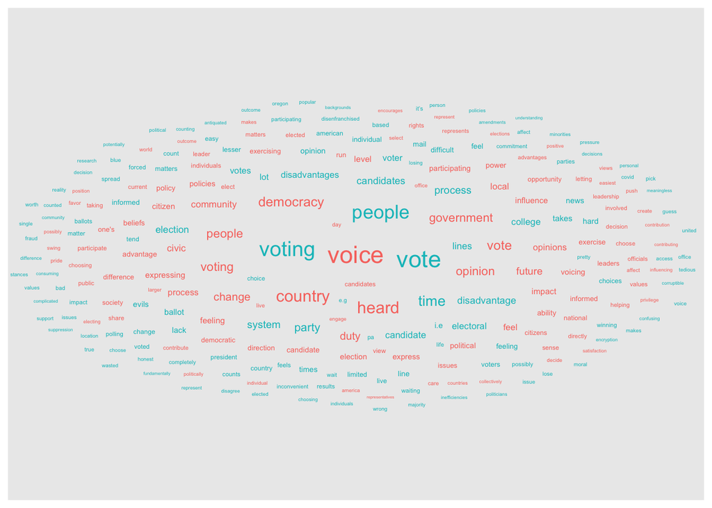

```r
counts %>%
  filter(n > 1) %>%
  ggplot(aes(label = word, size = n, color = name)) +
  geom_text_wordcloud_area(rm_outside = TRUE)
```

This time, let’s separate the advantages and disadvantages words into two separate panels with `facet_grid()`

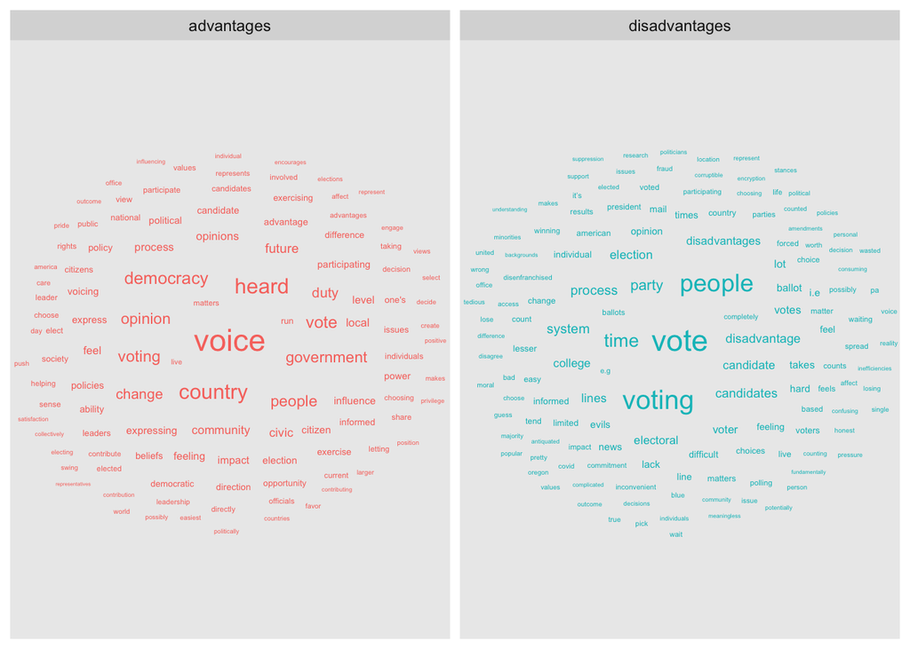

```r
counts %>%
  filter(n > 1) %>%
  ggplot(aes(label = word, size = n, color = name)) +
  geom_text_wordcloud_area(rm_outside = TRUE) +
  facet_grid(~name)
```

To make the most common words pop a little more, let’s change the max size

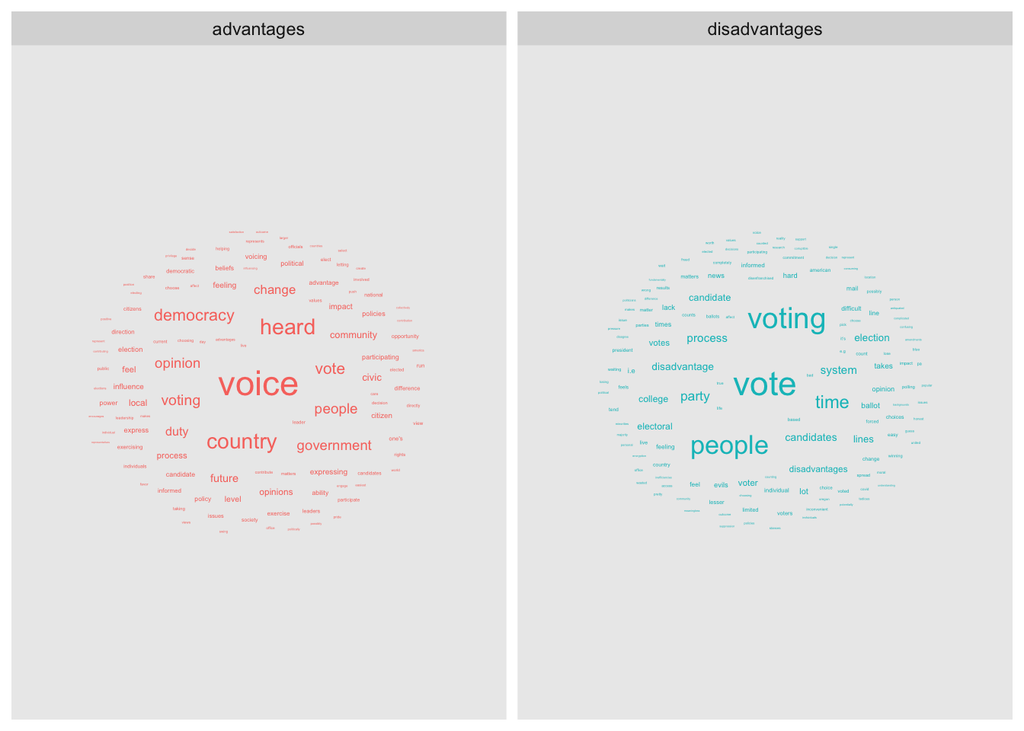

```r
counts %>%
  filter(n > 1) %>%
  ggplot(aes(label = word, size = n, color = name)) +
  geom_text_wordcloud_area(rm_outside = TRUE) +
  scale_size_area(max_size = 6) +
  facet_grid(~name)
```

# plot word counts

Next, let’s plot the word counts for each question as a bar graph

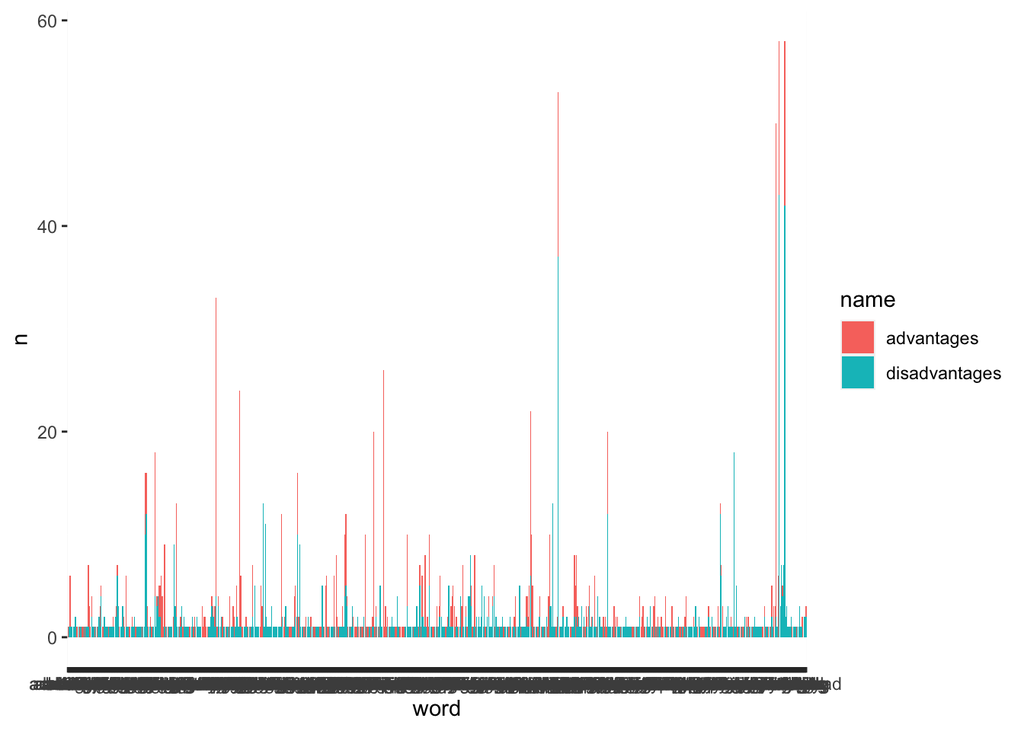

```r
counts %>%
  ggplot(aes(x = word, y = n, fill = name)) +
  geom_bar(stat = "identity")
```

Let’s reduce this down to 15 most common words per group

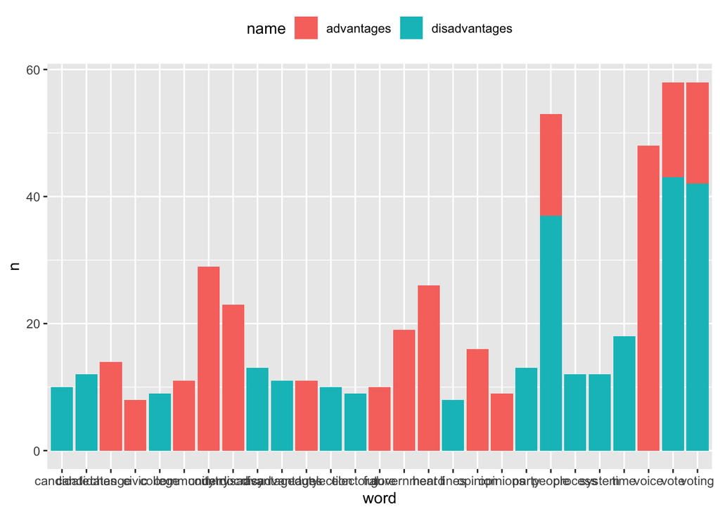

```r
advantages_15 = counts %>%
  filter(name == "advantages") %>%
  slice(1:15)

disadvantages_15 = counts %>%
  filter(name == "disadvantages") %>%
  slice(1:15)

bind_rows(advantages_15, disadvantages_15) %>%
  ggplot(aes(x = word, y = n, fill = name)) +
  geom_bar(stat = "identity") +
  theme(legend.position = "top")
```

To make this easier to read, let’s flip the x and y coordinates and use `position_dodge()` to separate the questions

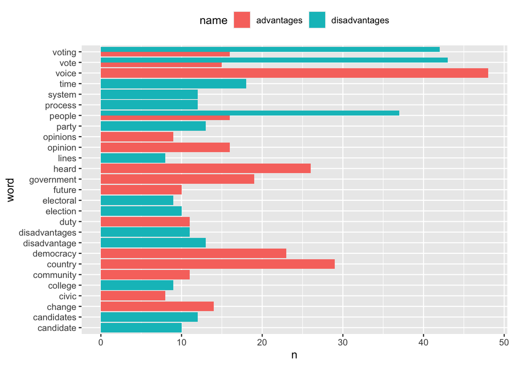

```r
bind_rows(advantages_15, disadvantages_15) %>%
  ggplot(aes(x = word, y = n, fill = name)) +
  geom_bar(stat = "identity", position = "dodge") +
  coord_flip() +
  theme(legend.position = "top")
```

Since the questions have different words, let’s instead use `facet_wrap` and `scales = "free` to create each question as a separate panel

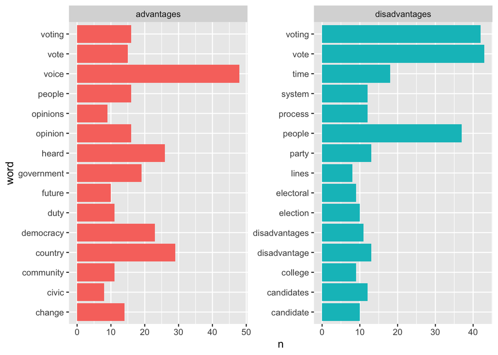

```r
bind_rows(advantages_15, disadvantages_15) %>%
  ggplot(aes(x = word, y = n, fill = name)) +
  geom_bar(stat = "identity", position = "dodge") +
  coord_flip() +
  facet_wrap(~name, scales = "free") +
  theme(legend.position = "none")
```

Let’s reorder the words by `n`

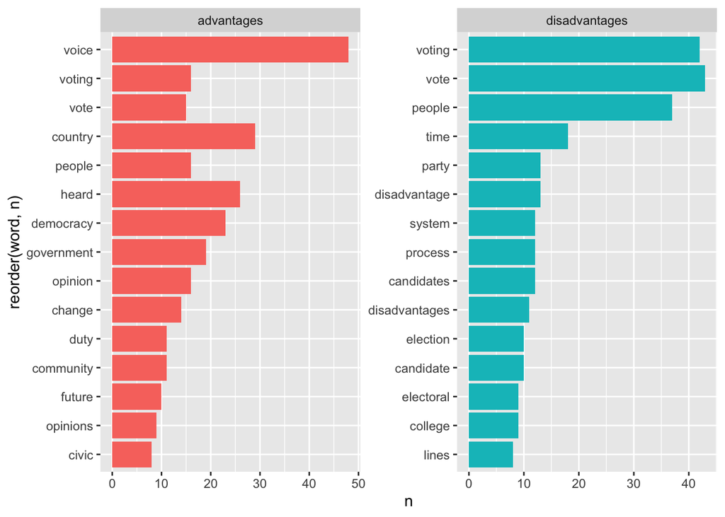

```r
bind_rows(advantages_15, disadvantages_15) %>%
  ggplot(aes(x = reorder(word, n), y = n, fill = name)) +
  geom_bar(stat = "identity", position = "dodge") +
  coord_flip() +
  facet_wrap(~name, scales = "free") +
  theme(legend.position = "none")
```

# sentiment

Next looks at the positive and negative sentiment expressed in the text. To do this, we’ll use the `get_sentiments` dataframe from the `{tidytext}` package and join the dataframes using `inner_join()` so that only rows with words that have a positive or negative sentiment remains

```r
data_tidy %>%
  select(ResponseId, advantages, disadvantages) %>%
  pivot_longer(cols = c(advantages, disadvantages)) %>%
  unnest_tokens(word, value) %>%
  inner_join(get_sentiments(lexicon = c("bing", "afinn", "loughran", "nrc"))) %>%
  select(-ResponseId)
```

| name | word | sentiment |
| --- | --- | --- |
| disadvantages | properly | positive |
| advantages | right | positive |
| disadvantages | tedious | negative |
| advantages | right | positive |
| advantages | greatest | positive |
| advantages | advantages | positive |
| disadvantages | winner | positive |
| disadvantages | loser | negative |
| disadvantages | support | positive |
| disadvantages | concern | negative |

[output cut: 306 more lines]

Next, we’ll get counts, but this time for the number of positive and negative words for each question separately

```r
data_tidy %>%
  select(ResponseId, advantages, disadvantages) %>%
  pivot_longer(cols = c(advantages, disadvantages)) %>%
  unnest_tokens(word, value) %>%
  inner_join(get_sentiments(lexicon = c("bing", "afinn", "loughran", "nrc"))) %>%
  group_by(name, sentiment) %>%
  count(sort = TRUE)
```

| name | sentiment | n |
| --- | --- | --- |
| disadvantages | negative | 128 |
| advantages | positive | 97 |
| disadvantages | positive | 77 |
| advantages | negative | 14 |

Let’s plot this as a bar graph

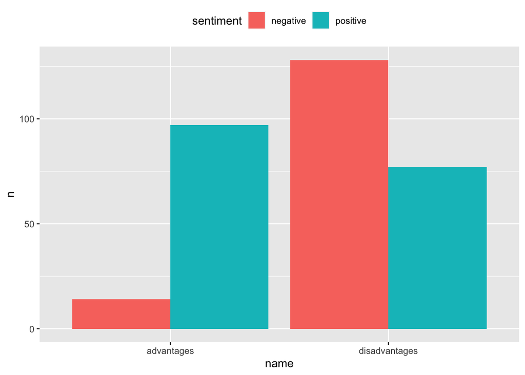

```r
data_tidy %>%
  select(ResponseId, advantages, disadvantages) %>%
  pivot_longer(cols = c(advantages, disadvantages)) %>%
  unnest_tokens(word, value) %>%
  inner_join(get_sentiments(lexicon = c("bing", "afinn", "loughran", "nrc"))) %>%
  group_by(name, sentiment) %>%
  count(sort = TRUE) %>%
  ggplot(aes(x = name, y = n, fill = sentiment)) +
  geom_bar(stat = "identity", position = "dodge") +
  theme(legend.position = "top")
```

Finally, let’s see if this differs by people who did and didn’t vote

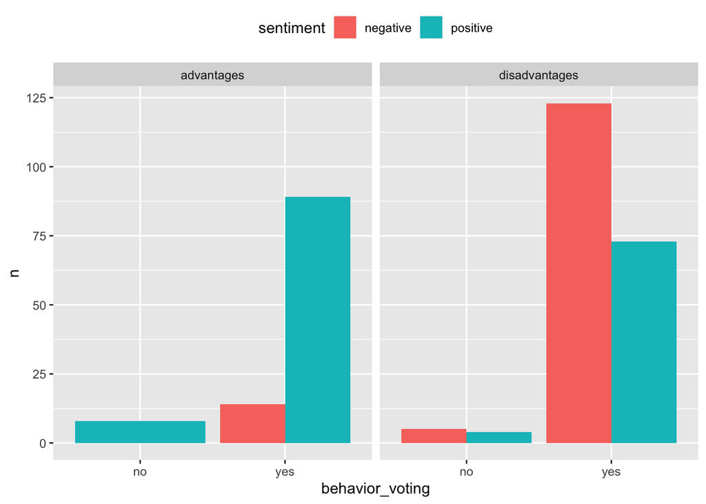

```r
data_tidy %>%
  select(ResponseId, advantages, disadvantages, behavior_voting) %>%
  pivot_longer(cols = c(advantages, disadvantages)) %>%
  unnest_tokens(word, value) %>%
  inner_join(get_sentiments(lexicon = c("bing", "afinn", "loughran", "nrc"))) %>%
  group_by(name, sentiment, behavior_voting) %>%
  count(sort = TRUE) %>%
  ggplot(aes(x = behavior_voting, y = n, fill = sentiment)) +
  geom_bar(stat = "identity", position = "dodge") +
  facet_grid(~name) +
  theme(legend.position = "top")
```

```r
data_tidy %>%
  group_by(behavior_voting) %>%
  summarize(n = n())
```

| behavior_voting | n |
| --- | --- |
| no | 15 |
| yes | 151 |

Since way more people voted than didn’t vote (hooray!!), let’s use percentages instead of count variables

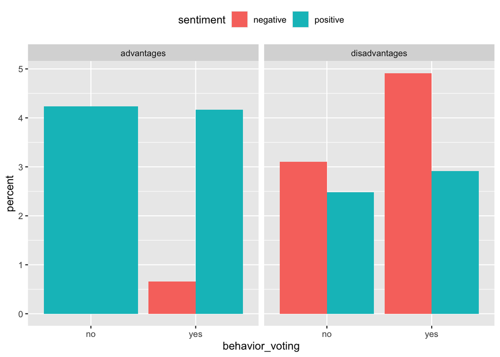

```r
total_words = data_tidy %>%
  select(ResponseId, advantages, disadvantages, behavior_voting) %>%
  pivot_longer(cols = c(advantages, disadvantages)) %>%
  unnest_tokens(word, value) %>%
  group_by(behavior_voting, name) %>%
  count(sort = TRUE) %>%
  rename("total_n" = n)

data_tidy %>%
  select(ResponseId, advantages, disadvantages, behavior_voting) %>%
  pivot_longer(cols = c(advantages, disadvantages)) %>%
  unnest_tokens(word, value) %>%
  inner_join(get_sentiments(lexicon = c("bing", "afinn", "loughran", "nrc"))) %>%
  group_by(name, sentiment, behavior_voting) %>%
  count(sort = TRUE) %>%
  left_join(., total_words) %>%
  mutate(percent = (n / total_n) * 100) %>%
  ggplot(aes(x = behavior_voting, y = percent, fill = sentiment)) +
  geom_bar(stat = "identity", position = "dodge") +
  facet_grid(~name) +
  theme(legend.position = "top")
```

# assignment

Create a table using `reactable()` to present the responses to the barriers and solutions questions. Check out the [reactable documentation](https://glin.github.io/reactable/) and make it fancy

Generate word counts for the barriers and solutions questions and save these as `counts`

Create a dataframe called `top10` that contains the 10 most commonly used words for both the barriers and solutions questions

Modify the following code to plot the word counts as a bar graph with each question as a separate panel

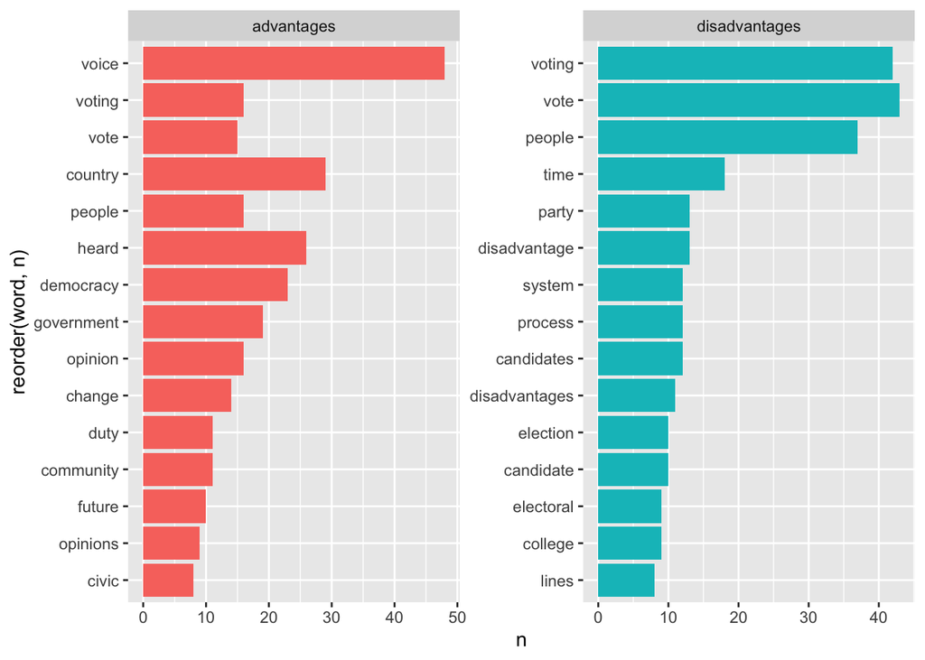

```r
bind_rows(advantages_15, disadvantages_15) %>%
  ggplot(aes(x = reorder(word, n), y = n, fill = name)) +
  geom_bar(stat = "identity", position = "dodge") +
  coord_flip() +
  facet_wrap(~name, scales = "free") +
  theme(legend.position = "none")
```

Modify the following code to explore whether people who voted use more negative language when describing barriers and more positive language when describing solutions

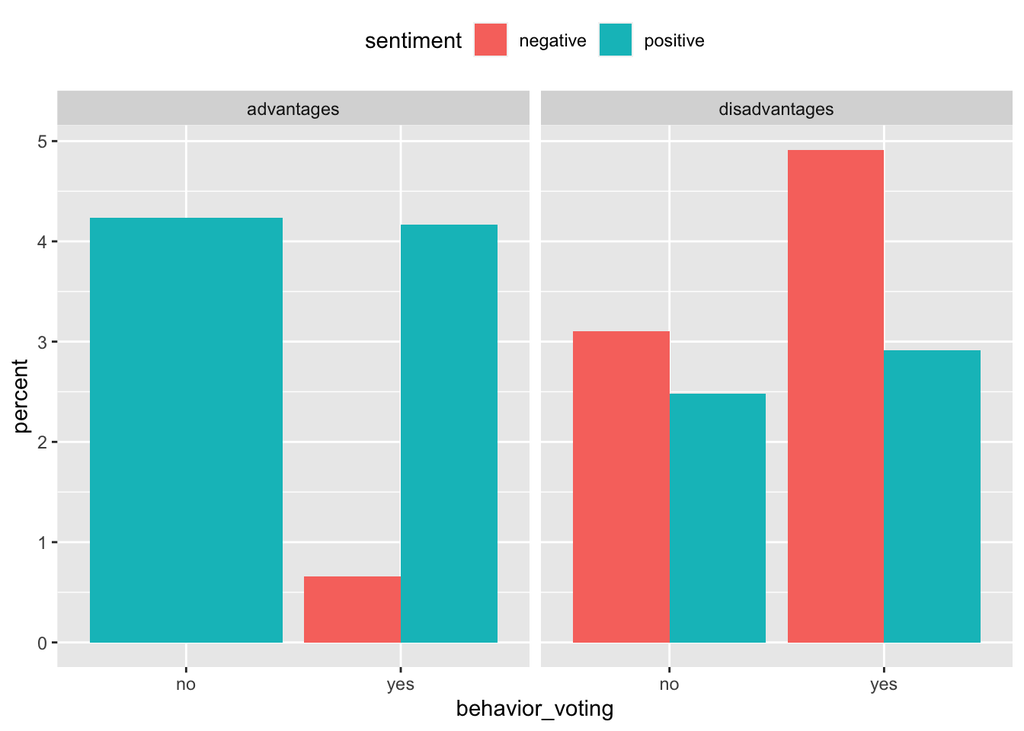

```r
total_words = data_tidy %>%
  select(ResponseId, advantages, disadvantages, behavior_voting) %>%
  pivot_longer(cols = c(advantages, disadvantages)) %>%
  unnest_tokens(word, value) %>%
  group_by(behavior_voting, name) %>%
  count(sort = TRUE) %>%
  rename("total_n" = n)

data_tidy %>%
  select(ResponseId, advantages, disadvantages, behavior_voting) %>%
  pivot_longer(cols = c(advantages, disadvantages)) %>%
  unnest_tokens(word, value) %>%
  inner_join(get_sentiments(lexicon = c("bing", "afinn", "loughran", "nrc"))) %>%
  group_by(name, sentiment, behavior_voting) %>%
  count(sort = TRUE) %>%
  left_join(., total_words) %>%
  mutate(percent = (n / total_n) * 100) %>%
  ggplot(aes(x = behavior_voting, y = percent, fill = sentiment)) +
  geom_bar(stat = "identity", position = "dodge") +
  facet_grid(~name) +
  theme(legend.position = "top")
```